# **MATH 3190 Homework 9**

Due April 9, 2026  
Focus: Notes 10  
Total Points: 70 + 10 (Self-Critique Comment and Uploading to GitHub) = 80

Note that your homework should be completed in Quarto. You can just add your answers and code to this document in the appropriate part. The file should be rendered as an html document or pdf document (html is quicker to render and you will need an installation of LaTeX to render as a pdf). You will “turn in” this homework by uploading the files, the .qmd and output file, to your GitHub `Math_3190_Assignment` repository in the `Homework/Homework_9` directory. Make sure all supporting files (if there are any) are in this directory as well. You should use `git` and `Unix` commands in a terminal for this (i.e. don’t manually upload files to GitHub). In addition, you will submit just your html or pdf file on Canvas to unlock the solutions.

Don’t forget to also put a self-critique comment on Canvas indicating what you did correctly and incorrectly and include any questions you may have about the assignment after submitting the assignment and thoroughly looking through the solutions.

# Problem 1 (70 points)

Before we begin, please re-install the `math3190package` since there was an update to the `classifier_plot()` function that is needed on this assignment. Use either `devtools::install_github("rbrown53/math3190package")` or  
`remotes::install_github("rbrown53/math3190package")`.

The National Institute of Diabetes and Digestive and Kidney Diseases conducted a study on 768 adult female Pima Native Americans living near Phoenix. The purpose of the study was to investigate factors related to diabetes. The response variable in this study (test) was whether or not the patient showed signs of diabetes (1 = yes, 0 = no). One explanatory variable considered was the plasma glucose concentration (in mg/dL) at 2 hours in an oral glucose tolerance test (glucose). Many other potential explanatory variables were considered as well including body mass index (BMI). The goal here is to predict the diabetes status of the subject, which is in the `results` variable.

### Part a (5 points)

Install and/or load the `faraway` package with the `pima` dataset. Set a seed and then split the data into a testing and a training set with the testing set containing 20% of the data values. When you do this, change the name of the variable “test” to “result” since it will be a bit confusing to call that test when we have a test dataset. Then make the `result` variable a factor so **R** treats it as categorical rather than numeric.

```r
library(faraway)
library(caret) |> suppressPackageStartupMessages()
library(dplyr) |> suppressPackageStartupMessages()
set.seed(3190)

data(pima)
pima <- pima |>
  rename(result = test)

pima$result <- as.factor(pima$result)

train_index <- createDataPartition(pima$result, p = 0.8, list = FALSE)

pima_train <- pima[train_index, ]
pima_test <- pima[-train_index, ]
```

### Part b (6 points)

- Fit a logistic regression model to the training set for predicting `result` from the `glucose` and `bmi` variables.
- Then use the `classifier_plot()` function in the `math3190package` (make sure you re-installed it!) to make a plot that shows the regions on the `glucose`-`bmi`-plane that are predicted to be 0 and 1. This shows how logistic regression divides the classes. Use the **training set** as the `data` input in this function.
- Next, obtain the predictions for the **test set** with a probability cutoff of 0.5 to predict if the person has diabetes. Create a confusion matrix using the `confusionMatrix()` function in the `caret` library. Make sure to put `positive = "1"` for this and all other confusion matrices on this assignment. Print all of the output from that function that shows the confusion matrix and many associated statistics.
- Write a sentence or two discussing how well this model performs in predicting on the test set.

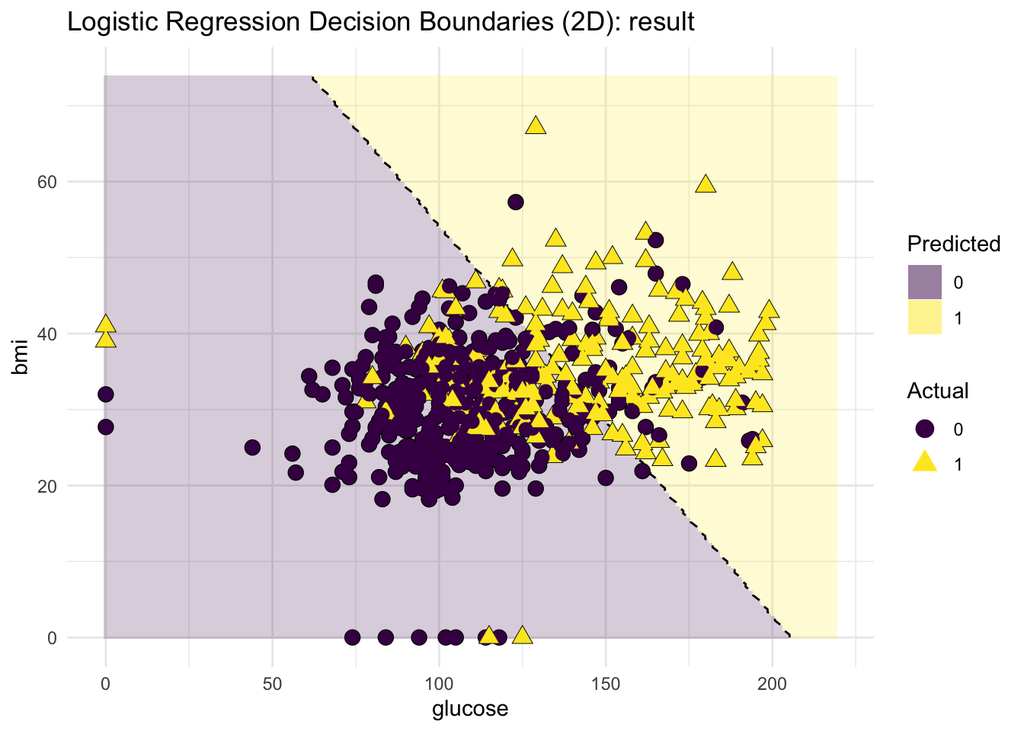

```r
library(math3190package) |> suppressPackageStartupMessages()

pima_mod = glm(result ~ glucose + bmi, data = pima_train, family = "binomial")
classifier_plot(pima_mod, pima_train)
```

```r
probability = predict(pima_mod, newdata = pima_test, type = "response")
predictions = ifelse(probability > 0.5, 1, 0)
predictions = as.factor(predictions)
confusionMatrix(predictions, pima_test$result, positive = "1")
```

```
Confusion Matrix and Statistics

          Reference
Prediction  0  1
         0 88 24
         1 12 29

               Accuracy : 0.7647
                 95% CI : (0.6894, 0.8294)
    No Information Rate : 0.6536
    P-Value [Acc > NIR] : 0.001988

                  Kappa : 0.4512

 Mcnemar's Test P-Value : 0.066753

            Sensitivity : 0.5472
            Specificity : 0.8800
         Pos Pred Value : 0.7073
         Neg Pred Value : 0.7857
             Prevalence : 0.3464
         Detection Rate : 0.1895
   Detection Prevalence : 0.2680
      Balanced Accuracy : 0.7136

       'Positive' Class : 1
```

This model performs with an accuracy of about 76%, which is pretty good. It has a strong specificity of 0.88, which means it pretty effectively identifies individuals without diabetes, but has a moderate sensitivity of 0.55, which means that it fails to detect diabetes in some individuals. Overall, the model seems to perform fairly well; it’s more reliable for predciting the absence of diabetes rather than the presence of diabetes.

### Part c (3 points)

Now let’s use naïve Bayes to get predictions. Use the `naive_bayes()` function in the `naivebayes` library to fit a model predicting result using `glucose` and `bmi`. Find the predicted probabilities of being a 0 and a 1 for the first observation in the training set.

```r
library(naivebayes) |> suppressPackageStartupMessages()
nb_mod <- naive_bayes(result ~ glucose + bmi, data = pima_train)
head(predict(nb_mod, type = "prob"))
```

```
             0          1
[1,] 0.4118944 0.58810564
[2,] 0.9174805 0.08251953
[3,] 0.1458582 0.85414176
[4,] 0.9016192 0.09838077
[5,] 0.3670842 0.63291582
[6,] 0.8520447 0.14795528
```

For the first observation in the training set there is about a 0.412 probability of being a 0 (no diabetes), and about a 0.588 probability of being a 1 (diabetes).

### Part d (9 points)

Now find the predicted probability of being a 0 and a 1 for the first observation in the training set “by hand” like we did in the notes on pages 187 and 188. To simplify this a bit, let’s again only use the variables `glucose` and `bmi` here. Of course, use **R** to help you (the `dnorm()` function and some tidyverse functions will be especially nice), but don’t use the `naive_bayes()` function here. Note: these variables we are using to predict are numeric, so we will assume a normal distribution for both of them (maybe not a good assumption, but let’s go with it). After you get the probabilities, compare them to the ones you got in part (c). They should match.

```r
x = pima_train[1, ]
p0 = mean(pima_train$result == 0)
p1 = mean(pima_train$result == 1)

t0 = filter(pima_train, result == 0)
t1 = filter(pima_train, result == 1)

g0_mean = mean(t0$glucose)
g0_sd = sd(t0$glucose)
b0_mean = mean(t0$bmi)
b0_sd = sd(t0$bmi)

g1_mean = mean(t1$glucose)
g1_sd = sd(t1$glucose)
b1_mean = mean(t1$bmi)
b1_sd = sd(t1$bmi)

l_g0 = dnorm(x$glucose, g0_mean, g0_sd)
l_b0 = dnorm(x$bmi, b0_mean, b0_sd)
l_g1 = dnorm(x$glucose, g1_mean, g1_sd)
l_b1 = dnorm(x$bmi, b1_mean, b1_sd)

num0 = p0 * l_g0 * l_b0
num1 = p1 * l_g1 * l_b1

prob_0 = num0 / (num0 + num1)
prob_1 = num1 / (num0 + num1)

prob_0
```

```
[1] 0.4118944
```

```r
prob_1
```

```
[1] 0.5881056
```

The probabilities were identical here to the probabilities in part c.

### Part e (3 points)

Now fit a naïve Bayes model predicting `result` from `glucose` and `bmi` using a kernel instead of assuming a normal distribution. You can do this by setting `usekernel = TRUE` in the `naive_bayes()` function.

```r
nb_kernel <- naive_bayes(result ~ glucose + bmi, data = pima_train, usekernel = TRUE)

predict(nb_kernel, type = "prob")[1, ]
```

```
        0         1
0.3885088 0.6114912
```

### Part f (5 points)

Now use the `classifier_plot()` function to make two plots: one using the first naïve Bayes from part (c) and one using the naïve Bayes with the kernel from part (e). Both should show the separation on the **training set**. Comment on how these models seems to perform in separating the results classes and if there seems like there may be any over-fitting here.

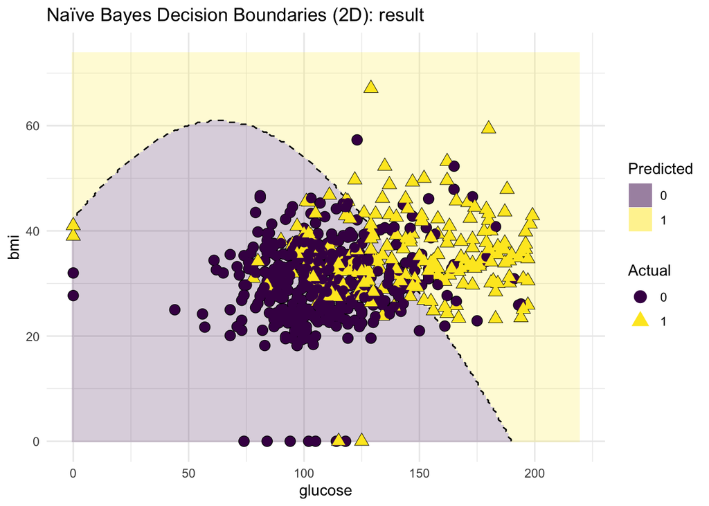

```r
classifier_plot(nb_mod, pima_train)
```

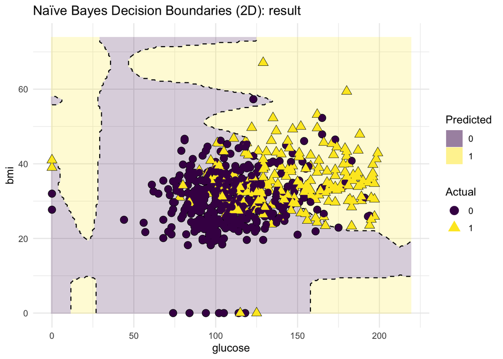

```r
classifier_plot(nb_kernel, pima_train)
```

There’s a lot of overlapping between the data, but it seems like the first naïve Bayes produces a smoother decision boundary, while the kernel naïve Bayes produces a more flexible and irregular boundary that follows the training data more closely. This suggests that the kernel could be capturing more complex patterns in the data, but it also might be overfitting and fitting noise in the training set as opposite to actual patterns.

### Part g (5 points)

Report the output of the `confusionMatrix()` function for both naïve Bayes models when predicting on the **test** set. Write a couple sentences comparing the confusion matrix statistics.

```r
prob_nb <- predict(nb_mod, newdata = pima_test, type = "prob")
pred_nb <- ifelse(prob_nb[,2] >= 0.5, 1, 0)
pred_nb <- as.factor(pred_nb)

confusionMatrix(pred_nb, pima_test$result, positive = "1")
```

```
Confusion Matrix and Statistics

          Reference
Prediction  0  1
         0 88 25
         1 12 28

               Accuracy : 0.7582
                 95% CI : (0.6824, 0.8237)
    No Information Rate : 0.6536
    P-Value [Acc > NIR] : 0.003479

                  Kappa : 0.4333

 Mcnemar's Test P-Value : 0.048520

            Sensitivity : 0.5283
            Specificity : 0.8800
         Pos Pred Value : 0.7000
         Neg Pred Value : 0.7788
             Prevalence : 0.3464
         Detection Rate : 0.1830
   Detection Prevalence : 0.2614
      Balanced Accuracy : 0.7042

       'Positive' Class : 1
```

```r
prob_kernel <- predict(nb_kernel, newdata = pima_test, type = "prob")
pred_kernel <- ifelse(prob_kernel[,2] >= 0.5, 1, 0)
pred_kernel <- as.factor(pred_kernel)

confusionMatrix(pred_kernel, pima_test$result, positive = "1")
```

```
Confusion Matrix and Statistics

          Reference
Prediction  0  1
         0 84 20
         1 16 33

               Accuracy : 0.7647
                 95% CI : (0.6894, 0.8294)
    No Information Rate : 0.6536
    P-Value [Acc > NIR] : 0.001988

                  Kappa : 0.471

 Mcnemar's Test P-Value : 0.617075

            Sensitivity : 0.6226
            Specificity : 0.8400
         Pos Pred Value : 0.6735
         Neg Pred Value : 0.8077
             Prevalence : 0.3464
         Detection Rate : 0.2157
   Detection Prevalence : 0.3203
      Balanced Accuracy : 0.7313

       'Positive' Class : 1
```

The first naïve Bayes model had slightly less accuracy at 0.7582 compared to the kernal naïve Bayes which had an accurate of 0.7647. The first naïve Bayes model also had a slightly lower sensitivity, but had a slightly higher specificity. The differences in accuracy between the models is small, but it does seem the kernel model has a better balance.

### Part h (3 points)

Now let’s use a support vector machine (SVM) for classifying diabetes using all other variables. We’ll use the `svm()` function in the `e1071` library. Fit a model with a **polynomial** kernel here with degree 3 (the default), a cost of 1 (also the default), and keep `scale = TRUE` (which is the default as well). Ideally, we would do a cross validation to select the cost, but we’ll do that for the next kernel.

```r
library(e1071)
svm_poly <- svm(result ~ ., data = pima_train, kernel = "polynomial", degree = 3, cost = 1, scale = TRUE)

svm_poly
```

```
Call:
svm(formula = result ~ ., data = pima_train, kernel = "polynomial",
    degree = 3, cost = 1, scale = TRUE)


Parameters:
   SVM-Type:  C-classification
 SVM-Kernel:  polynomial
       cost:  1
     degree:  3
     coef.0:  0

Number of Support Vectors:  334
```

### Part i (10 points)

Now let’s use a different kernel. Let’s use the radial kernel for the SVM. This has two tuning parameters: the cost and $\gamma$. Let’s use the `train()` function in the `caret` package to do 5-fold cross validation (set a seed, please) to select both of those parameters. However, the `train()` function uses $\sigma$ instead of $\gamma$ and $C$ instead of cost.

Use the `trainControl()` function with the `trControl` option and the `tuneGrid` option in the `train()` function to perform this cross-validation. For `sigma`, use `seq(0.1, 2, by = 0.1)` and for `C` also use `seq(0.1, 2, by = 0.1)`. Put `method = "svmRadial"` in the `train()` function as well so it knows to use a SVM with the radial kernel. You will need to install the `kernlab` package for this to work. Set a seed here as well.

By default, the “best” sigma and C values will be chosen with accuracy instead of Cohen’s kappa. Make sure to choose the best values using kappa (although both metrics may choose the same “best” values).

```r
library(kernlab)
library(caret)
set.seed(3190)

svm_radial <- train(result ~ ., method = "svmRadial", data = pima_train, trControl = trainControl(method ="cv", number = 5), tuneGrid = expand.grid(sigma = seq(0.1, 2, by = 0.1), C = seq(0.1, 2, by = 0.1)), metric = "Kappa")

svm_radial
```

```
Support Vector Machines with Radial Basis Function Kernel

615 samples
  8 predictor
  2 classes: '0', '1'

No pre-processing
Resampling: Cross-Validated (5 fold)
Summary of sample sizes: 492, 492, 492, 492, 492
Resampling results across tuning parameters:

  sigma  C    Accuracy   Kappa
  0.1    0.1  0.7593496   0.4069764550
  0.1    0.2  0.7739837   0.4684618814
  0.1    0.3  0.7723577   0.4652233764
  0.1    0.4  0.7626016   0.4489241815
  0.1    0.5  0.7723577   0.4716801062
  0.1    0.6  0.7707317   0.4684549486
  0.1    0.7  0.7691057   0.4663931135
  0.1    0.8  0.7658537   0.4617270948
  0.1    0.9  0.7609756   0.4513732060
  0.1    1.0  0.7609756   0.4499447678
  0.1    1.1  0.7577236   0.4424358254
  0.1    1.2  0.7560976   0.4394562594
  0.1    1.3  0.7560976   0.4407627904
  0.1    1.4  0.7560976   0.4419939834
  0.1    1.5  0.7560976   0.4419908925
  0.1    1.6  0.7577236   0.4463890092
  0.1    1.7  0.7577236   0.4476068734
  0.1    1.8  0.7560976   0.4445915247
  0.1    1.9  0.7528455   0.4371606230
  0.1    2.0  0.7528455   0.4361046513
  0.2    0.1  0.7008130   0.2003765949
  0.2    0.2  0.7544715   0.4160794747
  0.2    0.3  0.7560976   0.4319125262
  0.2    0.4  0.7642276   0.4550562801
  0.2    0.5  0.7658537   0.4621456028
  0.2    0.6  0.7560976   0.4443053007
  0.2    0.7  0.7544715   0.4413579340
  0.2    0.8  0.7577236   0.4498556713
```

[output cut: 360 more lines]

```
  2.0    0.9  0.6520325   0.0252485995
  2.0    1.0  0.6455285   0.0179259666
  2.0    1.1  0.6520325   0.0534957640
  2.0    1.2  0.6520325   0.0612147709
  2.0    1.3  0.6585366   0.0833372684
  2.0    1.4  0.6569106   0.0801197130
  2.0    1.5  0.6585366   0.0882561641
  2.0    1.6  0.6569106   0.0874955665
  2.0    1.7  0.6569106   0.0874955665
  2.0    1.8  0.6569106   0.0874955665
  2.0    1.9  0.6569106   0.0874955665
  2.0    2.0  0.6569106   0.0874955665

Kappa was used to select the optimal model using the largest value.
The final values used for the model were sigma = 0.1 and C = 0.5.
```

```r
svm_radial$bestTune
```

```
  sigma   C
5   0.1 0.5
```

### Part j (3 points)

Fit the SVM with the **radial** kernel using the `svm()` function and the cross-validated cost and $\gamma$ found in part (i).

```r
svm_radial_final <- svm(result ~ ., data = pima_train, kernel = "radial", cost = 0.5, gamma = 50, scale = TRUE)
```

### Part k (5 points)

Create the classifier plots for both SVM models and plot the training set and comment on how well these seem to separate the classes.

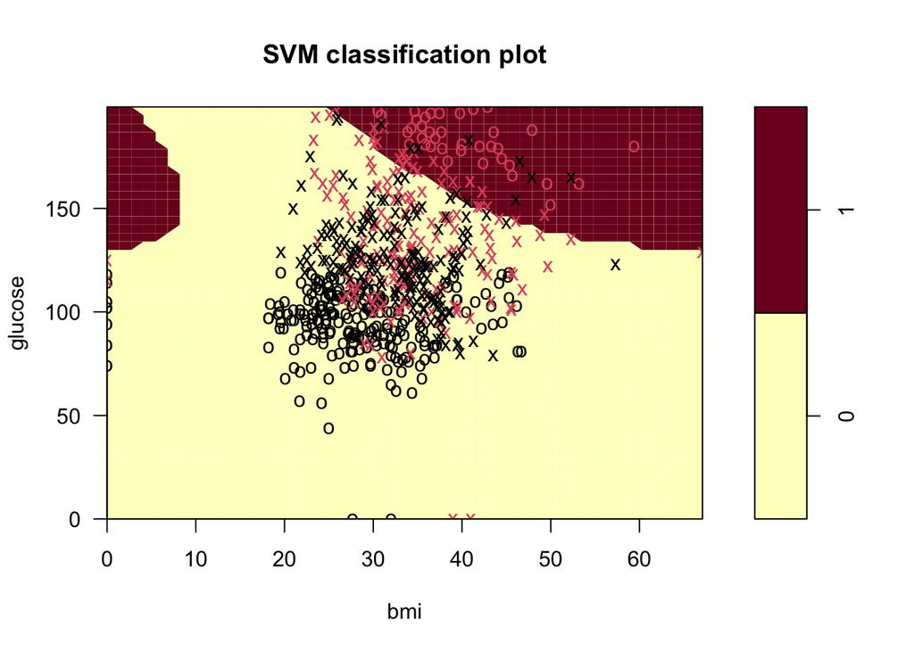

```r
svm_poly_plot <- svm(result ~ glucose + bmi, data = pima_train, kernel = "polynomial", scale = TRUE)

svm_radial_plot <- svm(result ~ glucose + bmi, data = pima_train, kernel = "radial", cost = 0.5, gamma = 50, scale = TRUE)

plot(svm_poly_plot, data = pima_train, glucose ~ bmi)
```

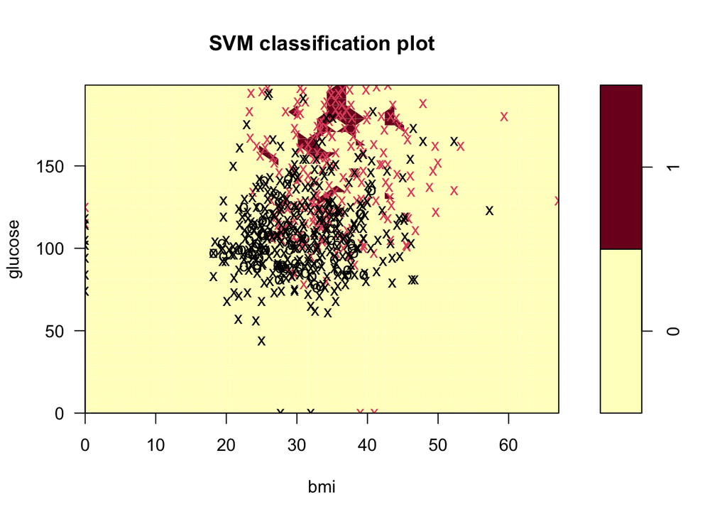

```r
plot(svm_radial_plot, data = pima_train, glucose ~ bmi)
```

### Part l (3 points)

Report the confusion matrix statistics for both SVM models when predicting the **test** set.

```r
poly_pred <- predict(svm_poly, newdata = pima_test)
radial_pred <- predict(svm_radial_final, newdata = pima_test)

confusionMatrix(poly_pred, pima_test$result)
```

```
Confusion Matrix and Statistics

          Reference
Prediction  0  1
         0 94 33
         1  6 20

               Accuracy : 0.7451
                 95% CI : (0.6684, 0.812)
    No Information Rate : 0.6536
    P-Value [Acc > NIR] : 0.009661

                  Kappa : 0.3605

 Mcnemar's Test P-Value : 3.136e-05

            Sensitivity : 0.9400
            Specificity : 0.3774
         Pos Pred Value : 0.7402
         Neg Pred Value : 0.7692
             Prevalence : 0.6536
         Detection Rate : 0.6144
   Detection Prevalence : 0.8301
      Balanced Accuracy : 0.6587

       'Positive' Class : 0
```

```r
confusionMatrix(radial_pred, pima_test$result)
```

```
Confusion Matrix and Statistics

          Reference
Prediction   0   1
         0 100  53
         1   0   0

               Accuracy : 0.6536
                 95% CI : (0.5725, 0.7286)
    No Information Rate : 0.6536
    P-Value [Acc > NIR] : 0.5373

                  Kappa : 0

 Mcnemar's Test P-Value : 9.148e-13

            Sensitivity : 1.0000
            Specificity : 0.0000
         Pos Pred Value : 0.6536
         Neg Pred Value :    NaN
             Prevalence : 0.6536
         Detection Rate : 0.6536
   Detection Prevalence : 1.0000
      Balanced Accuracy : 0.5000

       'Positive' Class : 0
```

### Part m (10 points)

Compare the output of the `confusionMarix()` function for all of our classifiers: the logistic regression model, the naïve Bayes with a normal assumption, the naïve Bayes using kernel density estimation, the SVM with a polynomial kernel, and the SVM using a radial kernel. Which was best? Which was worst? How different were the results? You can focus on the Cohen’s $\kappa$ and balanced accuracy for each one.